# Exercise 7.1 Logistic Regression

James Hooi

October 26, 2017

## Exercise instructions

Use the NH11 data set: 1. Use glm to conduct a logistic regression to predict ever worked (**everwrk**) using age (**age_p**) and marital status (**r_maritl**). 2. Predict the probability of working for each level of marital status.

Note that the data is not perfectly clean and ready to be modeled. You will need to clean up at least some of the variables before fitting the model.

## Initial data preparation

### Check data structure and summary

Libraries loaded: dplyr, mice, caTools, ROCR, ggplot2

```r
# Check out the data structure
  str(NH11)
```

```
## 'data.frame':    33014 obs. of  36 variables:
##  $ fmx     : chr  "01" "01" "01" "01" ...
##  $ fpx     : chr  "03" "03" "01" "01" ...
##  $ wtia_sa : num  7521 5784 2512 3086 12530 ...
##  $ wtfa_sa : num  8814 10427 2791 3888 16609 ...
##  $ region  : num  3 3 1 3 3 1 3 3 3 3 ...
##  $ strat_p : num  223 201 3 166 125 31 190 190 217 173 ...
##  $ psu_p   : num  1 2 1 1 2 1 1 1 1 1 ...
##  $ sex     : Factor w/ 2 levels "1 Male","2 Female": 2 2 2 2 2 2 2 2 1 1 ...
##  $ hispan_i: Factor w/ 13 levels "00 Multiple Hispanic",..: 13 13 13 13 13 13 7 13 13 13 ...
##  $ mracrpi2: Factor w/ 9 levels "01 White","02 Black/African American",..: 1 2 2 2 1 1 1 1 2 1 ...
##  $ age_p   : num  47 18 79 51 43 41 21 20 33 56 ...
##  $ r_maritl: Factor w/ 10 levels "0 Under 14 years",..: 6 8 5 7 2 2 8 8 8 2 ...
##  $ everwrk : Factor w/ 5 levels "1 Yes","2 No",..: NA NA 1 NA NA NA NA NA 1 1 ...
##  $ hypev   : Factor w/ 5 levels "1 Yes","2 No",..: 2 2 1 2 2 1 2 2 1 2 ...
```

[output cut: 25 more lines]

```r
# Take a subset of variables - all usable variables
  NH11_sub <- NH11 %>% select(-(fmx:wtfa_sa), -strat_p, -psu_p, -aasmyr, -(dibage:dibpill), -arthlmt, -(aflhca18:aldura18), -(cigsday:modmin), -ausualpl, -beddayr)
  summary(NH11_sub)
```

```
##      region            sex                                  hispan_i                                 mracrpi2         age_p                                  r_maritl                  everwrk                    hypev                     aasmev                    dibev                     arth1    …
##  Min.   :1.000   1 Male  :14811   12 Not Hispanic/Spanish origin:27147   01 White                        :25074   Min.   :18.00   1 Married - spouse in household:13943   1 Yes            :12153   1 Yes            :10672   1 Yes            : 4100   1 Yes            : 3242   1 Yes            : 8181…
##  1st Qu.:2.000   2 Female:18203   02 Mexican                    : 2181   02 Black/African American       : 5193   1st Qu.:33.00   7 Never married                : 7763   2 No             : 1887   2 No             :22296   2 No             :28882   2 No             :29260   2 No             :24788…
##  Median :3.000                    03 Mexican-American           : 1348   15 Other Asian (See file layout):  818   Median :47.00   5 Divorced                     : 4511   7 Refused        :   17   7 Refused        :   20   7 Refused        :    9   3 Borderline     :  485   7 Refused        :    8…
##  Mean   :2.713                    06 Central or South American  :  955   10 Chinese                      :  477   Mean   :48.11   4 Widowed                      : 3069   8 Not ascertained:    0   8 Not ascertained:    0   8 Not ascertained:    0   7 Refused        :   11   8 Not ascertained:    0…
##  3rd Qu.:4.000                    01 Puerto Rico                :  567   11 Filipino                     :  468   3rd Qu.:62.00   8 Living with partner          : 2002   9 Don't know     :    8   9 Don't know     :   26   9 Don't know     :   23   8 Not ascertained:    0   9 Don't know     :   37…
##  Max.   :4.000                    04 Cuban/Cuban American       :  295   09 Asian Indian                 :  403   Max.   :85.00   6 Separated                    : 1121   NA's             :18949                                                       9 Don't know     :   16                          …
##                                   (Other)                       :  521   (Other)                         :  581                   (Other)                        :  605                                                                                                                                  …
```

There are missing values in **everwrk**. Let’s collapse anything which isn’t a Yes or No into NA and investigate.

```r
  NH11_sub$everwrk <- factor(NH11_sub$everwrk, levels=c("1 Yes", "2 No"))
  head(NH11_sub[is.na(NH11_sub$everwrk),], 20)
```

```
##    region      sex                       hispan_i                                         mracrpi2 age_p                        r_maritl everwrk hypev aasmev        dibev arth1 wkdayr     smkev   bmi sleep
## 1       3 2 Female 12 Not Hispanic/Spanish origin                                         01 White    47                      5 Divorced    <NA>  2 No  1 Yes         2 No 1 Yes      3      2 No 99.99     6
## 2       3 2 Female 12 Not Hispanic/Spanish origin                        02 Black/African American    18                 7 Never married    <NA>  2 No   2 No         2 No  2 No      0      2 No 21.57     8
## 4       3 2 Female 12 Not Hispanic/Spanish origin                        02 Black/African American    51                     6 Separated    <NA>  2 No   2 No         2 No  2 No      0     1 Yes 99.99     8
## 5       3 2 Female 12 Not Hispanic/Spanish origin                                         01 White    43 1 Married - spouse in household    <NA>  2 No   2 No         2 No  2 No      1 7 Refused 99.99     9
## 6       1 2 Female 12 Not Hispanic/Spanish origin                                         01 White    41 1 Married - spouse in household    <NA> 1 Yes   2 No         2 No 1 Yes      0      2 No 26.63     8
## 7       3 2 Female   06 Central or South American                                         01 White    21                 7 Never married    <NA>  2 No   2 No         2 No  2 No      0      2 No 19.39     7
## 8       3 2 Female 12 Not Hispanic/Spanish origin                                         01 White    20                 7 Never married    <NA>  2 No   2 No         2 No  2 No      1      2 No 21.13     6
## 13      3   1 Male        04 Cuban/Cuban American                                         01 White    54 1 Married - spouse in household    <NA> 1 Yes   2 No         2 No  2 No      0     1 Yes 36.01     6
## 14      2   1 Male 12 Not Hispanic/Spanish origin                                         01 White    36                      5 Divorced    <NA>  2 No   2 No         2 No  2 No      0     1 Yes 25.63     7
## 16      4 2 Female 12 Not Hispanic/Spanish origin                                      11 Filipino    62                     6 Separated    <NA>  2 No   2 No         2 No  2 No      1      2 No 27.34     6
## 17      2 2 Female 12 Not Hispanic/Spanish origin                                         01 White    20 1 Married - spouse in household    <NA>  2 No   2 No         2 No  2 No     30     1 Yes 36.21     8
## 18      3 2 Female 12 Not Hispanic/Spanish origin                                         01 White    44 1 Married - spouse in household    <NA> 1 Yes   2 No         2 No  2 No      0     1 Yes 21.41     8
## 21      4   1 Male   06 Central or South American                                         01 White    39                 7 Never married    <NA>  2 No   2 No         2 No  2 No     10      2 No 99.99     7
## 22      3 2 Female 12 Not Hispanic/Spanish origin                                         01 White    63                      5 Divorced    <NA> 1 Yes   2 No 3 Borderline  2 No     10     1 Yes 34.57     8
## 24      4   1 Male 12 Not Hispanic/Spanish origin                 15 Other Asian (See file layout)    59 1 Married - spouse in household    <NA> 1 Yes   2 No         2 No  2 No      0     1 Yes 29.69     7
## 25      4 2 Female 12 Not Hispanic/Spanish origin 16 Primary race not releasable (See file layout)    37 1 Married - spouse in household    <NA>  2 No   2 No         2 No  2 No      0     1 Yes 24.45     7
## 26      4   1 Male 12 Not Hispanic/Spanish origin                 15 Other Asian (See file layout)    52 1 Married - spouse in household    <NA>  2 No   2 No         2 No  2 No      0      2 No 26.63     6
## 28      3   1 Male 12 Not Hispanic/Spanish origin                                         01 White    58 1 Married - spouse in household    <NA>  2 No   2 No         2 No  2 No      0      2 No 34.88     8
## 32      1 2 Female 12 Not Hispanic/Spanish origin                        02 Black/African American    30 1 Married - spouse in household    <NA>  2 No  1 Yes         2 No 1 Yes      6      2 No 99.99     4
## 36      2 2 Female 12 Not Hispanic/Spanish origin                                         01 White    73                      5 Divorced    <NA> 1 Yes   2 No         2 No  2 No      0     1 Yes 38.09     6
```

If **wkdayr** > 0 then **everwrk** must be Yes, impute these values.

```r
  NH11_sub[which(is.na(NH11_sub$everwrk) & NH11_sub$wkdayr > 0), "everwrk"] <- "1 Yes"
  summary(NH11_sub)
```

```
##      region            sex                                  hispan_i                                 mracrpi2         age_p                                  r_maritl      everwrk                    hypev                     aasmev                    dibev                     arth1           wkday…
##  Min.   :1.000   1 Male  :14811   12 Not Hispanic/Spanish origin:27147   01 White                        :25074   Min.   :18.00   1 Married - spouse in household:13943   1 Yes:20022   1 Yes            :10672   1 Yes            : 4100   1 Yes            : 3242   1 Yes            : 8181   Min.   : …
##  1st Qu.:2.000   2 Female:18203   02 Mexican                    : 2181   02 Black/African American       : 5193   1st Qu.:33.00   7 Never married                : 7763   2 No : 1887   2 No             :22296   2 No             :28882   2 No             :29260   2 No             :24788   1st Qu.: …
##  Median :3.000                    03 Mexican-American           : 1348   15 Other Asian (See file layout):  818   Median :47.00   5 Divorced                     : 4511   NA's :11105   7 Refused        :   20   7 Refused        :    9   3 Borderline     :  485   7 Refused        :    8   Median : …
##  Mean   :2.713                    06 Central or South American  :  955   10 Chinese                      :  477   Mean   :48.11   4 Widowed                      : 3069                 8 Not ascertained:    0   8 Not ascertained:    0   7 Refused        :   11   8 Not ascertained:    0   Mean   : …
##  3rd Qu.:4.000                    01 Puerto Rico                :  567   11 Filipino                     :  468   3rd Qu.:62.00   8 Living with partner          : 2002                 9 Don't know     :   26   9 Don't know     :   23   8 Not ascertained:    0   9 Don't know     :   37   3rd Qu.: …
##  Max.   :4.000                    04 Cuban/Cuban American       :  295   09 Asian Indian                 :  403   Max.   :85.00   6 Separated                    : 1121                                                                     9 Don't know     :   16                             Max.   :9…
##                                   (Other)                       :  521   (Other)                         :  581                   (Other)                        :  605                                                                                                                         NA's   :1…
```

There are still many missing values. Clean up race/ethnicity and delete records where **everwrk** is NA. We are also done with **wkdayr** so it can go.

```r
  NH11_sub <- NH11_sub %>% mutate(ethnicity = if_else(hispan_i != "12 Not Hispanic/Spanish origin", "04 Hispanic", as.character(mracrpi2)), ethnicity = factor(ethnicity, levels = unique(ethnicity))) %>% select(-hispan_i, -mracrpi2)

  NH11_sub <- NH11_sub %>% filter(!is.na(everwrk)) %>% select(-wkdayr)
  summary(NH11_sub)
```

```
##      region            sex            age_p                                  r_maritl     everwrk                    hypev                     aasmev                    dibev                     arth1                     smkev            bmi            sleep                                   ethn…
##  Min.   :1.000   1 Male  : 8876   Min.   :18.00   1 Married - spouse in household:8962   1 Yes:20022   1 Yes            : 8347   1 Yes            : 3077   1 Yes            : 2666   1 Yes            : 6684   1 Yes            : 9396   Min.   :11.81   Min.   : 3.000   01 White                       …
##  1st Qu.:2.000   2 Female:13033   1st Qu.:34.00   7 Never married                :4919   2 No : 1887   2 No             :13526   2 No             :18810   2 No             :18844   2 No             :15187   2 No             :12463   1st Qu.:23.57   1st Qu.: 6.000   04 Hispanic                    …
##  Median :3.000                    Median :51.00   5 Divorced                     :3011                 7 Refused        :   15   7 Refused        :    8   3 Borderline     :  377   7 Refused        :    7   7 Refused        :   17   Median :27.11   Median : 7.000   02 Black/African American      …
##  Mean   :2.713                    Mean   :50.74   4 Widowed                      :2718                 8 Not ascertained:    0   8 Not ascertained:    0   7 Refused        :   10   8 Not ascertained:    0   8 Not ascertained:   21   Mean   :30.16   Mean   : 8.073   15 Other Asian (See file layout…
##  3rd Qu.:4.000                    3rd Qu.:66.00   8 Living with partner          :1211                 9 Don't know     :   21   9 Don't know     :   14   8 Not ascertained:    0   9 Don't know     :   31   9 Don't know     :   12   3rd Qu.:31.68   3rd Qu.: 8.000   10 Chinese                     …
##  Max.   :4.000                    Max.   :85.00   6 Separated                    : 731                                                                     9 Don't know     :   12                                                       Max.   :99.99   Max.   :99.000   11 Filipino                    …
##                                                   (Other)                        : 357                                                                                                                                                                                    (Other)                        …
```

What about age, are there any anomalies?

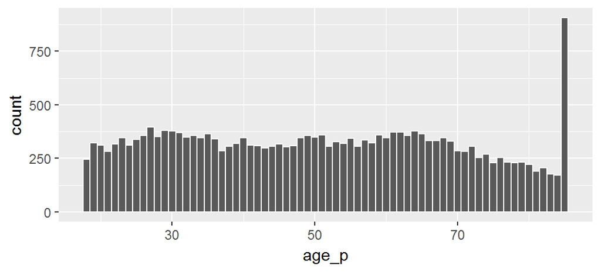

```r
  ggplot(NH11_sub, aes(x=age_p)) + geom_histogram(binwidth = 1, col="white")
```

It looks as if anyone over 85 has been marked with an age of 85 so we will need to filter out these records. Let’s also bracket age into 11-year buckets.

Clean up other variables. We need to remove “Unknown marital status” as it is not meaningful when modelling. We also re-leveled the **r_maritl** variable to approximate the usual chronology of status, otherwise coefficients may not be sensible (*Under 14 Years* and *Married - spouse in household unknown* did not have any records). We clean any other NAs and filter BMI for less than 75 and sleep less than 24 hours.

```r
  NH11_sub %>% group_by(r_maritl) %>% tally
```

```
## # A tibble: 8 x 2
##                              r_maritl     n
##                                <fctr> <int>
## 1     1 Married - spouse in household  8962
## 2 2 Married - spouse not in household   306
## 3                           4 Widowed  2718
## 4                          5 Divorced  3011
## 5                         6 Separated   731
## 6                     7 Never married  4919
## 7               8 Living with partner  1211
## 8            9 Unknown marital status    51
```

```r
  NH11_sub <- NH11_sub %>% filter(r_maritl != "9 Unknown marital status")
  NH11_sub$r_maritl <- factor(NH11_sub$r_maritl, levels = c("7 Never married", "8 Living with partner", "1 Married - spouse in household","2 Married - spouse not in household", "6 Separated", "5 Divorced", "4 Widowed", "0 Under 14 Years", "3 Married - spouse in household unknown"))
  levels(NH11_sub$r_maritl) <- c("1 Never married", "2 Living with partner", "3 Married - spouse in household", "4 Married - spouse not in household","5 Separated", "6 Divorced", "7 Widowed", "98 Under 14 Years", "99 Married - spouse in household unknown")
  NH11_sub$r_maritl <- as.factor(as.character(NH11_sub$r_maritl))

  NH11_sub <- NH11_sub %>% filter(age_p < 85) %>% mutate(age_p = factor(cut(age_p, breaks=6)))
  levels(NH11_sub$everwrk) <- c(1,0)

  NH11_sub <- NH11_sub %>%
    mutate(hypev = factor(NH11_sub$hypev, levels = c("1 Yes","2 No")), aasmev = factor(NH11_sub$aasmev, levels = c("1 Yes","2 No")), dibev = factor(NH11_sub$dibev, levels = c("1 Yes","2 No","3 Borderline")),
    arth1 = factor(NH11_sub$arth1, levels = c("1 Yes","2 No")), smkev = factor(NH11_sub$smkev, levels = c("1 Yes","2 No"))) %>%
    filter(bmi < 75 & sleep < 24 & !is.na(hypev) & !is.na(aasmev) & !is.na(dibev) & !is.na(arth1) & !is.na(smkev))
```

Ok, it’s all ready to go, we can convert independent variables to log numerics and move on.

```r
  NH11_subnorm <- NH11_sub %>% mutate_at(vars(-everwrk),.funs=as.numeric) %>% mutate_at(vars(-everwrk), .funs=log10)
  summary(NH11_subnorm)
```

```
##      region            sex             age_p           r_maritl      everwrk       hypev            aasmev           dibev            arth1            smkev             bmi            sleep          ethnicity
##  Min.   :0.0000   Min.   :0.0000   Min.   :0.0000   Min.   :0.0000   1:18484   Min.   :0.0000   Min.   :0.0000   Min.   :0.0000   Min.   :0.0000   Min.   :0.0000   Min.   :1.072   Min.   :0.4771   Min.   :0.0000
##  1st Qu.:0.3010   1st Qu.:0.0000   1st Qu.:0.3010   1st Qu.:0.3010   0: 1675   1st Qu.:0.0000   1st Qu.:0.3010   1st Qu.:0.3010   1st Qu.:0.0000   1st Qu.:0.0000   1st Qu.:1.372   1st Qu.:0.7782   1st Qu.:0.0000
##  Median :0.4771   Median :0.3010   Median :0.4771   Median :0.4771             Median :0.3010   Median :0.3010   Median :0.3010   Median :0.3010   Median :0.3010   Median :1.431   Median :0.8451   Median :0.0000
##  Mean   :0.3951   Mean   :0.1752   Mean   :0.4484   Mean   :0.4439             Mean   :0.1898   Mean   :0.2583   Mean   :0.2676   Mean   :0.2123   Mean   :0.1699   Mean   :1.438   Mean   :0.8463   Mean   :0.1814
##  3rd Qu.:0.6021   3rd Qu.:0.3010   3rd Qu.:0.6990   3rd Qu.:0.6990             3rd Qu.:0.3010   3rd Qu.:0.3010   3rd Qu.:0.3010   3rd Qu.:0.3010   3rd Qu.:0.3010   3rd Qu.:1.495   3rd Qu.:0.9031   3rd Qu.:0.3010
##  Max.   :0.6021   Max.   :0.3010   Max.   :0.7782   Max.   :0.8451             Max.   :0.3010   Max.   :0.3010   Max.   :0.4771   Max.   :0.3010   Max.   :0.3010   Max.   :1.858   Max.   :1.3424   Max.   :1.0000
```

## Logistic Regression Model

### Split out data in training and test sets, evaluate baseline model

```r
  # split data 65% training, 35% test
  set.seed(1000)
  split <- sample.split(NH11_subnorm$everwrk, SplitRatio = 0.65)
  NH11_subTrain <- subset(NH11_subnorm, split==TRUE)
  NH11_subTest <- subset(NH11_subnorm, split==FALSE)
  # evaluate baseline model, assume everyone works
  table(NH11_subTrain$r_maritl, NH11_subTrain$everwrk)
```

```
##
##                        1    0
##   0                 2662  441
##   0.301029995663981  730   38
##   0.477121254719662 5108  377
##   0.602059991327962  156   14
##   0.698970004336019  426   33
##   0.778151250383644 1815   55
##   0.845098040014257 1118  131
```

```r
  nrow(NH11_subTrain[NH11_subTrain$everwrk==1,])/nrow(NH11_subTrain)
```

```
## [1] 0.9168956
```

### Check for multicollinearity between chosen variables

```r
  NH11_subTrain_num <- sapply(NH11_subTrain, as.numeric)
  cor(NH11_subTrain_num)
```

```
##                  region           sex        age_p     r_maritl       everwrk        hypev       aasmev         dibev        arth1       smkev         bmi         sleep   ethnicity
## region     1.0000000000  0.0101690973 -0.037872862  0.026841447  0.0232334655 -0.003917711 -0.017420573 -0.0004684739  0.005091964  0.03325427 -0.00111912  0.0244627344  0.12038896
## sex        0.0101690973  1.0000000000  0.001571566  0.102344433  0.0967060148  0.030766690 -0.043798166  0.0328459211 -0.059880513  0.14156740 -0.02979643  0.0007498455  0.04294726
## age_p     -0.0378728617  0.0015715660  1.000000000  0.533870909 -0.1190066077 -0.433506929  0.033767589 -0.2216240371 -0.392090490 -0.17436848  0.11656364  0.0201290711 -0.14182594
## r_maritl   0.0268414471  0.1023444329  0.533870909  1.000000000 -0.1004731991 -0.242902927  0.003562329 -0.1141512608 -0.242370363 -0.12043957  0.07414352 -0.0259097008 -0.08272836
## everwrk    0.0232334655  0.0967060148 -0.119006608 -0.100473199  1.0000000000  0.045928725  0.013520732 -0.0007671875  0.059388355  0.13139036 -0.05422192  0.0551440878  0.20518041
## hypev     -0.0039177115  0.0307666897 -0.433506929 -0.242902927  0.0459287253  1.000000000  0.044267100  0.2792186212  0.312768307  0.11279968 -0.25205081  0.0187284354  0.05160451
## aasmev    -0.0174205731 -0.0437981657  0.033767589  0.003562329  0.0135207320  0.044267100  1.000000000  0.0373224195  0.109238211  0.04754956 -0.09243632  0.0529724394  0.01587016
## dibev     -0.0004684739  0.0328459211 -0.221624037 -0.114151261 -0.0007671875  0.279218621  0.037322420  1.0000000000  0.165481451  0.06325305 -0.19362938  0.0071353158 -0.02296270
## arth1      0.0050919639 -0.0598805125 -0.392090490 -0.242370363  0.0593883551  0.312768307  0.109238211  0.1654814508  1.000000000  0.13202569 -0.17210547  0.0602286200  0.12564436
## smkev      0.0332542701  0.1415673965 -0.174368483 -0.120439568  0.1313903628  0.112799684  0.047549558  0.0632530461  0.132025694  1.00000000 -0.03613716  0.0251469035  0.16254353
## bmi       -0.0011191204 -0.0297964301  0.116563638  0.074143521 -0.0542219242 -0.252050808 -0.092436318 -0.1936293806 -0.172105466 -0.03613716  1.00000000 -0.0694524906 -0.02484178
## sleep      0.0244627344  0.0007498455  0.020129071 -0.025909701  0.0551440878  0.018728435  0.052972439  0.0071353158  0.060228620  0.02514690 -0.06945249  1.0000000000 -0.03522798
## ethnicity  0.1203889640  0.0429472628 -0.141825943 -0.082728360  0.2051804131  0.051604505  0.015870160 -0.0229626988  0.125644356  0.16254353 -0.02484178 -0.0352279758  1.00000000
```

There seems to be slight multicollinearity between age and marital status, which makes sense since older people are more likely to have journeyed through the chronologically ordered marital statuses. There is also some correlation between age and medical conditions, and between medical conditions themselves, but no strong multicollinearity.

None of the x variables have a strong correlation with the y variable.

### Create logistic regression models

For the logistic regression model, let’s compare the results with and without age.

```r
  # per instructions
  everwrkLog1 <- glm(everwrk ~ r_maritl + age_p, data = NH11_subTrain, family = binomial)
  summary(everwrkLog1)
```

```
##
## Call:
## glm(formula = everwrk ~ r_maritl + age_p, family = binomial,
##     data = NH11_subTrain)
##
## Deviance Residuals:
##     Min       1Q   Median       3Q      Max
## -0.5846  -0.4296  -0.3632  -0.3289   2.5177
##
## Coefficients:
##             Estimate Std. Error z value Pr(>|z|)
## (Intercept) -1.68010    0.05523 -30.418  < 2e-16 ***
## r_maritl    -0.64324    0.13023  -4.939 7.85e-07 ***
## age_p       -1.16020    0.13710  -8.463  < 2e-16 ***
## ---
## Signif. codes:  0 '***' 0.001 '**' 0.01 '*' 0.05 '.' 0.1 ' ' 1
##
## (Dispersion parameter for binomial family taken to be 1)
##
##     Null deviance: 7503.0  on 13103  degrees of freedom
## Residual deviance: 7301.5  on 13101  degrees of freedom
## AIC: 7307.5
##
## Number of Fisher Scoring iterations: 5
```

```r
  # with all demographic variables
  everwrkLog2 <- glm(everwrk ~ ., data = NH11_subTrain, family = binomial)
  summary(everwrkLog2)
```

```
##
## Call:
## glm(formula = everwrk ~ ., family = binomial, data = NH11_subTrain)
##
## Deviance Residuals:
##     Min       1Q   Median       3Q      Max
## -1.3577  -0.4314  -0.3074  -0.2186   3.2325
##
## Coefficients:
##             Estimate Std. Error z value Pr(>|z|)
## (Intercept) -3.16487    0.68589  -4.614 3.95e-06 ***
## region      -0.04733    0.16396  -0.289 0.772821
## sex          2.46778    0.25075   9.842  < 2e-16 ***
## age_p       -0.86895    0.16353  -5.314 1.07e-07 ***
## r_maritl    -0.76355    0.13592  -5.618 1.93e-08 ***
## hypev       -0.52374    0.28959  -1.809 0.070515 .
## aasmev       0.22553    0.33331   0.677 0.498630
## dibev       -1.18298    0.36125  -3.275 0.001058 **
## arth1       -0.09190    0.30859  -0.298 0.765856
## smkev        2.35315    0.26406   8.911  < 2e-16 ***
## bmi         -1.24392    0.36642  -3.395 0.000687 ***
## sleep        2.44713    0.37950   6.448 1.13e-10 ***
## ethnicity    2.12342    0.11519  18.434  < 2e-16 ***
## ---
## Signif. codes:  0 '***' 0.001 '**' 0.01 '*' 0.05 '.' 0.1 ' ' 1
##
## (Dispersion parameter for binomial family taken to be 1)
##
##     Null deviance: 7503.0  on 13103  degrees of freedom
## Residual deviance: 6600.4  on 13091  degrees of freedom
## AIC: 6626.4
##
## Number of Fisher Scoring iterations: 6
```

Both models show significant predictor variables.

### Model evaluation

Let’s check model accuracy using t=0.5:

```r
  pred1 <- predict(everwrkLog1, type="response")
  table(NH11_subTrain$everwrk, pred1 >= 0.5)
```

```
##
##     FALSE
##   1 12015
##   0  1089
```

```r
  pred2 <- predict(everwrkLog2, type="response")
  table(NH11_subTrain$everwrk, pred2 >= 0.5)
```

```
##
##     FALSE  TRUE
##   1 11997    18
##   0  1075    14
```

```r
  (18+1075)/(nrow(NH11_subTrain))
```

```
## [1] 0.08340965
```

The first model actually did not predict any probabilities above 0.5 so the accuracy is unchanged from the baseline model. The second model managed an accuracy of only 8%!

So does either model have any way to distinguish between “ever having worked” or not?

```r
ROCR_pred1 <- prediction(pred1, NH11_subTrain$everwrk)
as.numeric(performance(ROCR_pred1, "auc")@y.values)
```

```
## [1] 0.3886689
```

```r
ROCR_pred2 <- prediction(pred2, NH11_subTrain$everwrk)
as.numeric(performance(ROCR_pred2, "auc")@y.values)
```

```
## [1] 0.2407055
```

Both AUCs are low. In the absence of better data, we’ll take the inverse of model 2 since it has the lower AUC (therefore the inverse is higher).

```r
  pred2 <- -predict(everwrkLog2, type="response")+1
  table(NH11_subTrain$everwrk, pred2 >= 0.5)
```

```
##
##     FALSE  TRUE
##   1    18 11997
##   0    14  1075
```

```r
  (11997+14)/nrow(NH11_subTrain)
```

```
## [1] 0.9165904
```

```r
  ROCR_pred2 <- prediction(pred2, NH11_subTrain$everwrk)
  as.numeric(performance(ROCR_pred2, "auc")@y.values)
```

```
## [1] 0.7592945
```

This time the model managed a prediction accuracy of 91.65% at t=0.5, or about the same as the baseline. Let’s look at the ROC Curve to see what threshold value might work better.

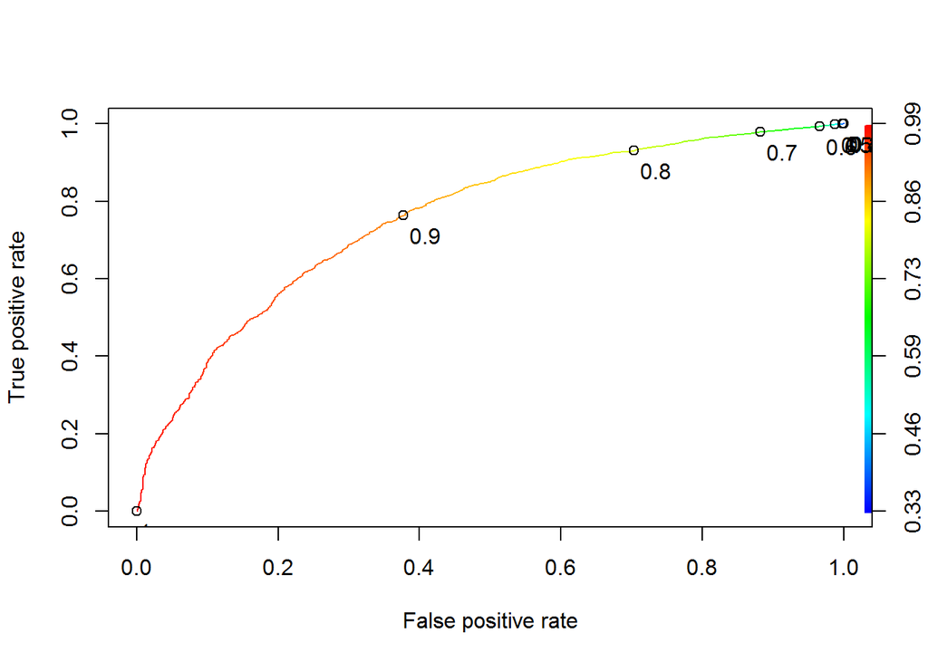

```r
ROCR_perf2 = performance(ROCR_pred2, "tpr", "fpr")
plot(ROCR_perf2, colorize=TRUE, print.cutoffs.at = seq(0, 1, 0.1), text.adj = c(-0.2, 1.7))
```

Well, it looks like that is about the best we can do so let’s just stay with the baseline model!